# Predict Weight Lifting Quality based on Activity Monitors

### Executive Summary

This project aims to predict the quality of weight lifting exercises based on activity monitors. It does so by using machine learning techniques on a data set provided by http://groupware.les.inf.puc-rio.br/har. The variable we are trying to predict has 5 possible values (A, B, C, D or E) with A denoting that the activity took place correctly and the other 4 meaning that there was a specific error in how the activity took place.

We tried 4 models and the results for the best of them (based on cross-validation) were very promising. This proved to be true when we submitted the 20 predictions to Coursera as all of them were correct.

### Data

The data comes from accelerometers on the belt, forearm, arm, and dumbell of 6 participants as they were performing barbell lifts. They were asked to perform the exercises in 5 different ways (variable *classe*), one of them being the correct one and the other ones being worng in specific aspects.

We start with preparing our R environment and exploring the data structure.

#### Load libraries and Data set

```r
library(randomForest)
library(caret)
```

```r
set.seed(12345)
training_loaded <- read.csv("http://d396qusza40orc.cloudfront.net/predmachlearn/pml-training.csv", na.strings = c(" ","","NA"))
testing_loaded <- read.csv("http://d396qusza40orc.cloudfront.net/predmachlearn/pml-testing.csv", na.strings = c(" ","","NA"))
```

We then look at our data sets.

#### Structure (first 30 columns)

```r
str(training_loaded[1:30])
```

```
## 'data.frame':    19622 obs. of  30 variables:
##  $ X                   : int  1 2 3 4 5 6 7 8 9 10 ...
##  $ user_name           : Factor w/ 6 levels "adelmo","carlitos",..: 2 2 2 2 2 2 2 2 2 2 ...
##  $ raw_timestamp_part_1: int  1323084231 1323084231 1323084231 1323084232 1323084232 1323084232 1323084232 1323084232 1323084232 1323084232 ...
##  $ raw_timestamp_part_2: int  788290 808298 820366 120339 196328 304277 368296 440390 484323 484434 ...
##  $ cvtd_timestamp      : Factor w/ 20 levels "02/12/2011 13:32",..: 9 9 9 9 9 9 9 9 9 9 ...
##  $ new_window          : Factor w/ 2 levels "no","yes": 1 1 1 1 1 1 1 1 1 1 ...
##  $ num_window          : int  11 11 11 12 12 12 12 12 12 12 ...
##  $ roll_belt           : num  1.41 1.41 1.42 1.48 1.48 1.45 1.42 1.42 1.43 1.45 ...
##  $ pitch_belt          : num  8.07 8.07 8.07 8.05 8.07 8.06 8.09 8.13 8.16 8.17 ...
##  $ yaw_belt            : num  -94.4 -94.4 -94.4 -94.4 -94.4 -94.4 -94.4 -94.4 -94.4 -94.4 ...
##  $ total_accel_belt    : int  3 3 3 3 3 3 3 3 3 3 ...
##  $ kurtosis_roll_belt  : Factor w/ 396 levels "-0.016850","-0.021024",..: NA NA NA NA NA NA NA NA NA NA ...
##  $ kurtosis_picth_belt : Factor w/ 316 levels "-0.021887","-0.060755",..: NA NA NA NA NA NA NA NA NA NA ...
##  $ kurtosis_yaw_belt   : Factor w/ 1 level "#DIV/0!": NA NA NA NA NA NA NA NA NA NA ...
```

[output cut: 16 more lines]

#### First few rows and columns

```r
head(training_loaded[,1:30])
```

```
##   X user_name raw_timestamp_part_1 raw_timestamp_part_2   cvtd_timestamp
## 1 1  carlitos           1323084231               788290 05/12/2011 11:23
## 2 2  carlitos           1323084231               808298 05/12/2011 11:23
## 3 3  carlitos           1323084231               820366 05/12/2011 11:23
## 4 4  carlitos           1323084232               120339 05/12/2011 11:23
## 5 5  carlitos           1323084232               196328 05/12/2011 11:23
## 6 6  carlitos           1323084232               304277 05/12/2011 11:23
##   new_window num_window roll_belt pitch_belt yaw_belt total_accel_belt
## 1         no         11      1.41       8.07    -94.4                3
## 2         no         11      1.41       8.07    -94.4                3
## 3         no         11      1.42       8.07    -94.4                3
## 4         no         12      1.48       8.05    -94.4                3
## 5         no         12      1.48       8.07    -94.4                3
## 6         no         12      1.45       8.06    -94.4                3
##   kurtosis_roll_belt kurtosis_picth_belt kurtosis_yaw_belt
```

[output cut: 34 more lines]

#### Size

```r
dim(training_loaded)
```

```
## [1] 19622   160
```

```r
dim(testing_loaded)
```

```
## [1]  20 160
```

#### NA Values Investigation

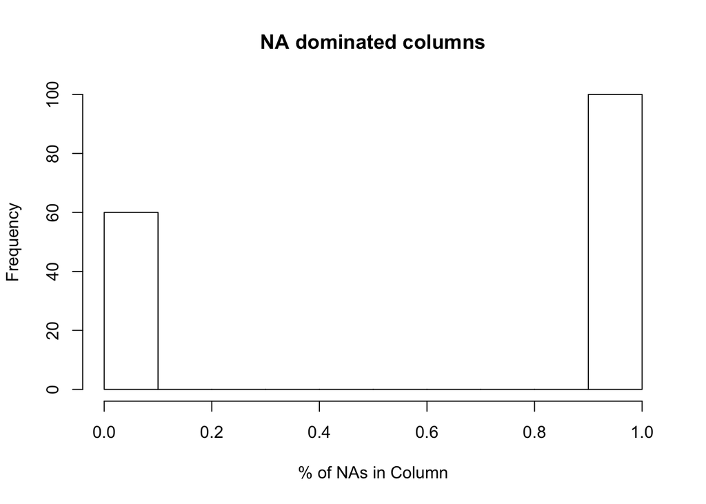

```r
hist((colSums(sapply(training_loaded, is.na))/dim(training_loaded)[1]), main="NA dominated columns", xlab="% of NAs in Column")
```

As we can see from the histogram above, there are many columns (~100) that have primarily been populated with NA values. We have decided to exclude these from our model as they do not provide any signal. We have also decided to exclude the first 7 columns that do not provide accelerometer data.

```r
training <- training_loaded[,(colSums(sapply(training_loaded, is.na))/dim(training_loaded)[1]) < 0.9][-(1:7)]
evaluation <- testing_loaded[,(colSums(sapply(training_loaded, is.na))/dim(training_loaded)[1]) < 0.9][-(1:7)]
```

### Model Approach

```r
intrain <- createDataPartition(training$classe, p=0.7, list=FALSE)
train <- training[intrain,]
test <- training[-intrain,]
```

### Model Implementation and Cross Validation

We will try four Random Forest models with different settings for *ntree* and *mtry*. While the Random Forest models will give us an Out Of Bag error estimation, we will also use them to predict *classe* for our test data set and then calculate the confusion matrix and the test (Out of Sample) error. This cross-validation technique makes sure we avoid choosing a model that has overfitted. The randomForest() function enables us to create the model and run it for test and get all the results in a simple call:

```r
model_rf1 <- randomForest(classe ~ ., data=train, xtest=test[,-53], ytest=test[,53], ntree=100, mtry=7, keep.forest=TRUE); model_rf1
```

```
##
## Call:
##  randomForest(formula = classe ~ ., data = train, xtest = test[,      -53], ytest = test[, 53], ntree = 100, mtry = 7, keep.forest = TRUE)
##                Type of random forest: classification
##                      Number of trees: 100
## No. of variables tried at each split: 7
##
##         OOB estimate of  error rate: 0.66%
## Confusion matrix:
##      A    B    C    D    E class.error
## A 3901    4    0    1    0 0.001280082
## B   18 2633    7    0    0 0.009405568
## C    0   20 2367    9    0 0.012103506
## D    0    0   19 2230    3 0.009769094
## E    1    1    3    5 2515 0.003960396
##                 Test set error rate: 0.8%
## Confusion matrix:
##      A    B    C   D    E class.error
## A 1672    2    0   0    0 0.001194743
## B    8 1127    4   0    0 0.010535558
## C    0   12 1012   2    0 0.013645224
## D    0    0   15 949    0 0.015560166
## E    0    0    0   4 1078 0.003696858
```

```r
model_rf2 <- randomForest(classe ~ ., data=train, xtest=test[,-53], ytest=test[,53], ntree=100, mtry=14, keep.forest=TRUE); model_rf2
```

```
##
## Call:
##  randomForest(formula = classe ~ ., data = train, xtest = test[,      -53], ytest = test[, 53], ntree = 100, mtry = 14, keep.forest = TRUE)
##                Type of random forest: classification
##                      Number of trees: 100
## No. of variables tried at each split: 14
##
##         OOB estimate of  error rate: 0.67%
## Confusion matrix:
##      A    B    C    D    E class.error
## A 3901    4    0    0    1 0.001280082
## B   14 2631   13    0    0 0.010158014
## C    0   13 2375    8    0 0.008764608
## D    0    1   20 2225    6 0.011989343
## E    1    0    7    4 2513 0.004752475
##                 Test set error rate: 0.66%
## Confusion matrix:
##      A    B    C   D    E class.error
## A 1671    3    0   0    0 0.001792115
## B    7 1130    2   0    0 0.007901668
## C    0    6 1016   4    0 0.009746589
## D    0    0   12 952    0 0.012448133
## E    0    0    0   5 1077 0.004621072
```

```r
model_rf3 <- randomForest(classe ~ ., data=train, xtest=test[,-53], ytest=test[,53], ntree=500, mtry=7, keep.forest=TRUE); model_rf3
```

```
##
## Call:
##  randomForest(formula = classe ~ ., data = train, xtest = test[,      -53], ytest = test[, 53], ntree = 500, mtry = 7, keep.forest = TRUE)
##                Type of random forest: classification
##                      Number of trees: 500
## No. of variables tried at each split: 7
##
##         OOB estimate of  error rate: 0.54%
## Confusion matrix:
##      A    B    C    D    E  class.error
## A 3904    1    1    0    0 0.0005120328
## B   13 2638    7    0    0 0.0075244545
## C    0   16 2377    3    0 0.0079298831
## D    0    0   22 2228    2 0.0106571936
## E    0    0    3    6 2516 0.0035643564
##                 Test set error rate: 0.7%
## Confusion matrix:
##      A    B    C   D    E  class.error
## A 1673    1    0   0    0 0.0005973716
## B   10 1127    2   0    0 0.0105355575
## C    0   10 1016   0    0 0.0097465887
## D    0    0   13 951    0 0.0134854772
## E    0    0    0   5 1077 0.0046210721
```

```r
model_rf4 <- randomForest(classe ~ ., data=train, xtest=test[,-53], ytest=test[,53], ntree=500, mtry=14, keep.forest=TRUE); model_rf4
```

```
##
## Call:
##  randomForest(formula = classe ~ ., data = train, xtest = test[,      -53], ytest = test[, 53], ntree = 500, mtry = 14, keep.forest = TRUE)
##                Type of random forest: classification
##                      Number of trees: 500
## No. of variables tried at each split: 14
##
##         OOB estimate of  error rate: 0.53%
## Confusion matrix:
##      A    B    C    D    E  class.error
## A 3904    1    0    0    1 0.0005120328
## B   17 2634    7    0    0 0.0090293454
## C    0   13 2376    7    0 0.0083472454
## D    0    0   18 2232    2 0.0088809947
## E    0    0    1    6 2518 0.0027722772
##                 Test set error rate: 0.71%
## Confusion matrix:
##      A    B    C   D    E class.error
## A 1671    3    0   0    0 0.001792115
## B    9 1126    4   0    0 0.011413521
## C    0    6 1017   3    0 0.008771930
## D    0    0   12 952    0 0.012448133
## E    0    0    0   5 1077 0.004621072
```

As we can see from the above we will choose **model #2** as it has the lowest test error.

### Final Predictions on the Evaluation Set

Now that we have selected our model and it performs well on the test set we will apply that model to the evaluation set. We will also create one file for each prediction we need to make from that set (20 in total). The code below does that and also shows on screen the 20 predictions. We uploaded the created files to Coursera and got 20/20 correct.

```r
pml_write_files = function(x) {
  n = length(x)
  for(i in 1:n) {
    filename = paste0("problem_id_",i,".txt")
    write.table(x[i],file=filename,quote=FALSE,row.names=FALSE,col.names=FALSE)
  }
}

predictions <- predict(model_rf2, newdata=evaluation); predictions
```

```
##  1  2  3  4  5  6  7  8  9 10 11 12 13 14 15 16 17 18 19 20
##  B  A  B  A  A  E  D  B  A  A  B  C  B  A  E  E  A  B  B  B
## Levels: A B C D E
```

```r
setwd("~/Dropbox/Projects/Learning/8.\ Practical\ Machine\ Learning/Exercises/Project/Answers\ Submitted")
pml_write_files(as.character(predictions))
```